# primer_selection_v.0.0.2

Hongxi

2023-11-28

# 引物设计流程

v.0.0.2  
更新：  
1. 更新了Tm值的算法，现在使用的是改良后的最邻近法，其公式为：  
$\Delta H = \frac{\Delta H}{\Delta S+A+Rln(\frac{C}{4})}-273.15+mlog[Na^+]$  
其中，$\Delta H$和$\Delta S$通过查表并累加可得。A为起始螺旋起始所需的一个常数，R为气体常数，C为DNA单链的浓度，m则是钠离子浓度的对数的系数。该公式的各个参数可能需要后续实验进行校准。  
2. 由于目前的Tm值算法与GC含量高度相关，GC含量的筛选条件现已设为默认不使用  
3. 计算Tm值时会顺便返回引物与互补链结合的自由能，但该信息未在最终结果中被提取出来

后续计划：  
1. 计算扩增子(50-150bp)的Tm值,有望用于SYBR相关的熔解曲线预测  
2. 增加对于重复序列的检测  
3. 增加基于序列相似性或自由能的打分系统，有望对于结果进行排序  
3.1. 基于计划3，完善序列比对功能  
4. 二级结构预测  
5. 优化比对函数，更快的运行速度 6. 输入序列的保守区域预测 7. 引物的种间特异性检测

## 定义所需函数

```r
#清理参数并记录时间
rm(list = ls())
start_time <- Sys.time()

#配置函数
##获取反向DNA序列(5'-3')
reverseDNA <- function(DNA) {
  q1 <- c("A","G","C","T")
  q2 <- c("T","C","G","A")

  names(q2)=q1

  F_seq <- DNA
  R_seq <- paste(rev(q2[unlist(strsplit(F_seq,""))]),collapse = "")

  return(R_seq)
}

##序列比对函数:返回相同序列的个数（包括反向序列上的）
align_all <- function(query,subject) {

  c_query <- reverseDNA(DNA=query)

  F_matches <- str_count(subject,query)
  R_matches <- str_count(subject,c_query)

  all_matches <- F_matches + R_matches
  return(all_matches)
}

##GC含量函数
GC_contain <- function(DNA) {
  GC <- (str_count(DNA, "G")+str_count(DNA, "C"))/nchar(DNA)*100
  GC <- round(GC,2)
  return(GC)
}

##计算Tm值与自由能并合为一个向量输出
get_Tm_G <- function(seq,value_table,C_Na=0.05,C_seq=2.5e-7,tem=37,A=-0.0108,R=0.001987) {
  get_pairs <- function(sequence) {
    pairs <- sapply(1:(nchar(sequence)-1),function(i){
      substr(sequence,i,i+1)
    })
    return(pairs)
  }

  adjacent_pairs <- get_pairs(seq)

  H_values <- sum(value_table$H[match(adjacent_pairs,value_table$seq)])
  S_values <- sum(value_table$S[match(adjacent_pairs,value_table$seq)])

  H_init <- sum(value_table$init_H[match(c(adjacent_pairs[1],adjacent_pairs[length(adjacent_pairs)]),value_table$seq)])
  S_init <- sum(value_table$init_S[match(c(adjacent_pairs[1],adjacent_pairs[length(adjacent_pairs)]),value_table$seq)])

  G <- (H_values+H_init) - (tem+273.15)*(S_values+S_init)
  Tm <- H_values/(S_values+A+R*log(C_seq/4))-273.15+(11.4*log10(C_Na))

  return(c(Tm,G))
}

##获取字符串中特定长度的子集并标注位置
get_all_primers <- function(minsize, maxsize, DNAsize, DNAseq) {

  get_primer_positions <- function(minsize, maxsize, DNAsize) {

    primer_size_range <- minsize:maxsize

    get_position <- function(DNAsize,primer_size) {
    startpoint <- 1:(DNAsize - primer_size + 1)
    endpoint <- primer_size:DNAsize

    temdata <- data.frame(start = startpoint, end = endpoint)

    return(temdata)
    }

    position_list <- mapply(get_position,
                            DNAsize = DNAsize,
                            primer_size = primer_size_range)

    position_map <- lapply(data.frame(position_list), as.list)

    primer_all_position <- do.call(bind_rows, position_map)
    primer_all_position$accession <- 1:length(primer_all_position$start)

    return(primer_all_position)
  }

  primer_positions <- get_primer_positions(minsize = minsize,
                                           maxsize = maxsize,
                                           DNAsize = DNAsize)

  primer_positions$seq <- str_sub(DNAseq, start = primer_positions$start, end = primer_positions$end)

  return(primer_positions)
}
```

## 加载所需要的包

该流程需要使用以下常用处理字符串的包：  
1. `stringr`  
2. `dplyr`  
3. `tidyr`

运行以下代码加载包

```r
#加载包
library(stringr)
library(dplyr)
library(tidyr)
```

## 开始分析

```r
#加载数据并初步处理
setwd("C:/Users/Hongxi/Documents/R_project")

input_path <- "./sequences/18S_rRNA_N1.txt"

NN_values <- read.csv("./scripts/NN_values.csv")
F_DNA <- paste(readLines(input_path), collapse = "")
R_DNA <- reverseDNA(DNA = F_DNA)
```

```r
#目标序列基础分析
target_size <- nchar(F_DNA)

target_GC <- GC_contain(F_DNA)
```

## 单条引物的预筛选

根据引物大小，使用本流程预先设定的函数`get_all_primers`选出所有长度范围内的子序列以减少运算量。

```r
#输入引物大小限制

primer_size_min <- 18
primer_size_max <- 23

#获取潜在引物序列
F_primer_all <- get_all_primers(minsize = primer_size_min,
                                maxsize = primer_size_max,
                                DNAsize = target_size,
                                DNAseq = F_DNA)
R_primer_all <- get_all_primers(minsize = primer_size_min,
                                maxsize = primer_size_max,
                                DNAsize = target_size,
                                DNAseq = R_DNA)
```

## 单条引物的筛选

其中,引物自身配对的限制是为了尽量避免发卡结构和引物二聚体的产生，与靶标的3端限制是为了避免与靶标的非特异性扩增。但是这种方法无法准确排除发卡结构和引物二聚体，因此外部软件的介入可能是必要的。

调整相关参数（GC含量、Tm范围、引物自身3端配对上限（含）、引物与靶标配对上限（含））后运行以下代码，可得两个分别包含正反向可用单条引物的数据框

```r
#单引物筛选
##计算CG含量(此处应该可以优化)
F_primer_all$GC <- sapply(as.list(F_primer_all$seq), GC_contain)
R_primer_all$GC <- sapply(as.list(R_primer_all$seq), GC_contain)

##计算Tm和自由能
F_Tm_G <- sapply(as.list(F_primer_all$seq),get_Tm_G,value_table = NN_values)
R_Tm_G <- sapply(as.list(R_primer_all$seq),get_Tm_G,value_table = NN_values)

F_primer_all$Tm <- F_Tm_G[1,]
F_primer_all$G <- F_Tm_G[2,]

R_primer_all$Tm <- R_Tm_G[1,]
R_primer_all$G <- R_Tm_G[2,]

rm(F_Tm_G,R_Tm_G)

##设定Tm阈值 (后期tm阈值应与GC含量协同)
Tm_min <- 58
Tm_max <- 63

##根据Tm值筛选
F_primer <- subset(F_primer_all, subset = Tm >= Tm_min & Tm <= Tm_max)
R_primer <- subset(R_primer_all, subset = Tm >= Tm_min & Tm <= Tm_max)
```

```r
##输入引物3端配对数上限
self_match_max <- 5
##引物3端自身配对筛选
F_primer$reversed_tail <- str_sub(sapply(as.list(F_primer$seq),reverseDNA), end = self_match_max)
F_primer$self_tail_match <- str_count(F_primer$seq,F_primer$reversed_tail)


R_primer$reversed_tail <- str_sub(sapply(as.list(R_primer$seq),reverseDNA), end = self_match_max)
R_primer$self_tail_match <- str_count(R_primer$seq,R_primer$reversed_tail)

F_primer <- subset(F_primer,
                   subset = self_tail_match == 0,
                   select = c("accession","seq","start","end","GC","Tm"))
R_primer <- subset(R_primer,
                   subset = self_tail_match == 0,
                   select = c("accession","seq","start","end","GC","Tm"))


##输入引物3端与靶标配对数上限
target_match_max <-7
##引物3端与靶标筛选
F_primer$tail <- str_sub(F_primer$seq, - target_match_max)
F_primer$tail_match <- mapply(align_all, as.list(F_primer$tail), as.list(F_primer$seq))

R_primer$tail <- str_sub(R_primer$seq, - target_match_max)
R_primer$tail_match <- mapply(align_all, as.list(R_primer$tail), as.list(R_primer$seq))

F_primer <- subset(F_primer,
                   subset = tail_match == 1,
                   select = c("accession","seq","start","end","GC","Tm"))
colnames(F_primer) <- c("F_accession", "F_seq", "F_start", "F_end","F_GC","F_Tm")

R_primer <- subset(R_primer,
                   subset = tail_match == 1,
                   select = c("accession","seq","start","end","GC","Tm"))
colnames(R_primer) <- c("R_accession", "R_seq", "R_start", "R_end","R_GC","R_Tm")

#查看前20行引物所在的数据框
print(F_primer[1:20,])
```

```
## # A tibble: 20 × 6
##    F_accession F_seq              F_start F_end  F_GC  F_Tm
##          <int> <chr>                <int> <int> <dbl> <dbl>
##  1         173 ACATGCCGACGGGCGCTG     173   190  72.2  58.6
##  2         174 CATGCCGACGGGCGCTGA     174   191  72.2  58.3
##  3         175 ATGCCGACGGGCGCTGAC     175   192  72.2  58.4
##  4         176 TGCCGACGGGCGCTGACC     176   193  77.8  60.6
##  5         177 GCCGACGGGCGCTGACCC     177   194  83.3  61.7
##  6         178 CCGACGGGCGCTGACCCC     178   195  83.3  61.2
##  7         179 CGACGGGCGCTGACCCCC     179   196  83.3  61.2
##  8         180 GACGGGCGCTGACCCCCT     180   197  77.8  59.7
##  9         181 ACGGGCGCTGACCCCCTT     181   198  72.2  58.9
## 10         182 CGGGCGCTGACCCCCTTC     182   199  77.8  58.6
## 11         183 GGGCGCTGACCCCCTTCG     183   200  77.8  58.6
## 12         184 GGCGCTGACCCCCTTCGC     184   201  77.8  59.2
## 13         185 GCGCTGACCCCCTTCGCG     185   202  77.8  59.4
## 14         186 CGCTGACCCCCTTCGCGG     186   203  77.8  58.8
## 15         187 GCTGACCCCCTTCGCGGG     187   204  77.8  58.6
## 16         188 CTGACCCCCTTCGCGGGG     188   205  77.8  58.1
## 17         192 CCCCCTTCGCGGGGGGGA     192   209  83.3  61.8
## 18         193 CCCCTTCGCGGGGGGGAT     193   210  77.8  59.4
## 19         194 CCCTTCGCGGGGGGGATG     194   211  77.8  58.2
## 20         195 CCTTCGCGGGGGGGATGC     195   212  77.8  58.8
```

```r
print(R_primer[1:20,])
```

```
## # A tibble: 20 × 6
##    R_accession R_seq              R_start R_end  R_GC  R_Tm
##          <int> <chr>                <int> <int> <dbl> <dbl>
##  1          81 CTCAGCGCTCCGCCAGGG      81    98  77.8  58.6
##  2          82 TCAGCGCTCCGCCAGGGC      82    99  77.8  60.5
##  3          83 CAGCGCTCCGCCAGGGCC      83   100  83.3  61.9
##  4          86 CGCTCCGCCAGGGCCGTG      86   103  83.3  61.7
##  5          87 GCTCCGCCAGGGCCGTGG      87   104  83.3  61.6
##  6          88 CTCCGCCAGGGCCGTGGG      88   105  83.3  61.1
##  7          93 CCAGGGCCGTGGGCCGAC      93   110  83.3  61.3
##  8          94 CAGGGCCGTGGGCCGACC      94   111  83.3  61.3
##  9          95 AGGGCCGTGGGCCGACCC      95   112  83.3  62.5
## 10         108 GACCCCGGCGGGGCCGAT     108   125  83.3  62.5
## 11         109 ACCCCGGCGGGGCCGATC     109   126  83.3  62.5
## 12         112 CCGGCGGGGCCGATCCGA     112   129  83.3  62.3
## 13         113 CGGCGGGGCCGATCCGAG     113   130  83.3  60.9
## 14         114 GGCGGGGCCGATCCGAGG     114   131  83.3  60.8
## 15         115 GCGGGGCCGATCCGAGGG     115   132  83.3  60.8
## 16         116 CGGGGCCGATCCGAGGGC     116   133  83.3  60.8
## 17         117 GGGGCCGATCCGAGGGCC     117   134  83.3  60.7
## 18         118 GGGCCGATCCGAGGGCCT     118   135  77.8  59.3
## 19         286 CGGGTTACCCGCGCCTGC     286   303  77.8  59.4
## 20         287 GGGTTACCCGCGCCTGCC     287   304  77.8  59.3
```

## 额外限制条件

此外，有资料表明引物3端避开密码子的第三位也能提升扩增效率。值得注意的是，也有相关论点认为过多的GC在3端聚集可能会导致非特异性扩增。后续在单个引物的筛选阶段加入该限制可能也是有必要的。

该代码块默认不运行，需要时可选择单独运行。 ~~

启用GC筛选（可选,默认关闭）

## 引物对的筛选

与单个引物筛选类似，此处使用的筛选条件有：  
1. 扩增子长度  
2. 引物对的Tm差异  
3. 引物间的3端连续配对个数  
4. 引物间任一连续碱基配对个数

在大部分资料中，限制引物间的配对主要是由认为选择的标准，如5bp或7bp。其本质在于考虑引物序列的互补链的相似性，可能后期可以将BLAST比对使用到其中，或者设计一个打分规则判断引物对的可用性。可能需要检测引物对的外部软件如IDT以获得高质量的结果。

调整扩增子长度、引物Tm差值、引物间3端配对上限（含）、引物间任意互补上限（含）后运行以下代码，符合条件的引物对（包括其序列、5-3端位置、GC含量、Tm值）将被放于数据框中并输出。

该步骤运算量较大，通常需要20s，但根据靶标序列的变大和限制条件的放松，运算时间可能会达数分钟。

```r
#引物对筛选
##输入引物对限制条件
pcr_max <- 100
pcr_min <- 50

deltar_Tm <- 2

##获取潜在引物对表,并根据限制筛选

get_all_primer_sets <- function(F_primer,R_primer,target_size,pcr_min,pcr_max,deltar_Tm,end_match, total_match){

  F_primer_list <- split(F_primer,F_primer$F_accession)

  get_primer_sets <- function(f_primer_data,r_primer_data, target_size, pcr_min, pcr_max, deltar_Tm) {

      primer_sets <- merge(f_primer_data,r_primer_data, all = T)

      primer_sets$pcr_length <- target_size-(primer_sets$R_start+primer_sets$F_start)
      primer_sets$pcr_distance <- target_size -(primer_sets$R_end + primer_sets$F_end)
      primer_sets$D_Tm <- primer_sets$R_Tm - primer_sets$F_Tm

      primer_sets <- subset(primer_sets,
                              subset = pcr_length >= pcr_min
                            & pcr_length <= pcr_max
                            & pcr_distance >= 0
                            & D_Tm <= deltar_Tm
                            & D_Tm >= -deltar_Tm,
                              select = c("R_seq", "R_start", "R_end","R_GC","R_Tm", "F_seq", "F_start", "F_end","F_GC","F_Tm","pcr_length"))

      return(primer_sets)
  }

  primer_sets_list <-lapply(F_primer_list,get_primer_sets,
                            f_primer_data = R_primer,
                            target_size = target_size,
                            pcr_min=pcr_min,
                            pcr_max=pcr_max,
                            deltar_Tm = deltar_Tm)

  primer_sets <- do.call(rbind,primer_sets_list)

  return(primer_sets)
}

primer_sets_all <- get_all_primer_sets(F_primer=F_primer,R_primer=R_primer,target_size=target_size,pcr_min=pcr_min,pcr_max=pcr_max,deltar_Tm = deltar_Tm)

##根据引物间3端互补性筛选(可使用正则表达式优化)
end_match_length <- 5

primer_sets_all$R_tail <- str_sub(primer_sets_all$R_seq, -end_match_length)
primer_sets_all$F_tail <- str_sub(primer_sets_all$F_seq, -end_match_length)

primer_sets_all$total_tail_match <- mapply(align_all, as.list(primer_sets_all$F_tail), as.list(primer_sets_all$R_seq))+mapply(align_all, as.list(primer_sets_all$R_tail), as.list(primer_sets_all$F_seq))

primer_sets_all <- subset(primer_sets_all,
                          subset = total_tail_match == 0,
                          select = c("R_seq", "R_start", "R_end","R_GC","R_Tm", "F_seq", "F_start", "F_end","F_GC","F_Tm","pcr_length"))

##根据引物间任意互补性筛选
total_match_length <- 7

align_between_primers <- function(q1,q2,length){

  select_pattern <- paste0(".{",length,"}")

  any_match_q1 <- any(str_detect(q1,str_extract_all(q2, pattern = select_pattern)[[1]]))
  any_match_q2 <- any(str_detect(q2,str_extract_all(q1, pattern = select_pattern)[[1]]))
  return(any_match_q1 == T | any_match_q2== T)
}

primer_sets_all$any_pair_match <- mapply(align_between_primers,as.list(primer_sets_all$R_seq),as.list(primer_sets_all$F_seq),length = total_match_length)

primer_sets <- subset(primer_sets_all,
                      subset = any_pair_match == F,
                      select = c("R_seq", "R_start", "R_end","R_GC","R_Tm", "F_seq", "F_start", "F_end","F_GC","F_Tm","pcr_length"))

print(primer_sets[sample(nrow(primer_sets), 15), ])
```

```
##                              R_seq R_start R_end  R_GC     R_Tm
## 9645.591      TTTGCGCGCCTGCTGCCTTC    1384  1403 65.00 60.03603
## 8560.1457  CTGGTGGTGCCCTTCCGTCAATT     649   671 56.52 58.80465
## 736.1150    CCCGCGGGACACTCAGCTAAGA    1082  1103 63.64 59.47120
## 10004.89        TCCAGGCGGCTCGGGCCT    1023  1040 77.78 61.06499
## 9679.1186   GTCACTACCTCCCCGGGTCGGG    1353  1374 72.73 61.72561
## 10351.1462 GCTTTGCAACCATACTCCCCCCG     685   707 60.87 59.73789
## 10746.437     GCCTGCCGGCGTAGGGTAGG     298   317 75.00 60.61440
## 6956.1016   AATCTCGGGTGGCTGAACGCCA     392   413 59.09 59.67611
## 7327.1313  TCCTTCCGCAGGTTCACCTACGG       7    29 60.87 59.59130
## 2594.100        CGGGCCCCGCGGGACACT    1077  1094 83.33 62.59306
## 10161.785    TTCGCTCTGGTCCGTCTTGCG     873   893 61.90 58.16865
## 9362.405       CGCGAAGGGGGTCAGCGCC    1668  1686 78.95 61.76106
## 10326.1482 TTTGGTTTCCCGGAAGCTGCCCG     720   742 60.87 61.36698
## 5436.939    CGACCGTCTTCTCAGCGCTCCG      71    92 68.18 60.77992
## 10403.1070  CTGGTGGTGCCCTTCCGTCAAT     649   670 59.09 58.40521
##                              F_seq F_start F_end  F_GC     F_Tm pcr_length
## 9645.591   GTGACCACGGGTGACGGGGAATC     395   417 65.22 60.93862         90
## 8560.1457   GGTTCCGGGGGGAGTATGGTTG    1158  1179 63.64 58.39427         62
## 736.1150        CGCCCCTTGCCTCTCGGC     736   753 77.78 58.93150         51
## 10004.89   GCCCCCTCGATGCTCTTAGCTGA     754   776 60.87 59.54855         92
## 9679.1186  CCGGAGAGGGAGCCTGAGAAACG     429   451 65.22 60.22473         87
## 10351.1462 TGCGGCGGCGTTATTCCCATGAC    1101  1123 60.87 61.30567         83
## 10746.437  TGATGCCCTTAGATGTCCGGGGC    1496  1518 60.87 59.92052         75
## 6956.1016    CTAGTTACGCGACCCCCGAGC    1403  1423 66.67 58.15300         74
## 7327.1313    CTGGCGGAGCGCTGAGAAGAC    1774  1794 66.67 58.91459         88
## 2594.100       TTGCCTCTCGGCGCCCCCT     742   760 73.68 61.40617         50
## 10161.785  CCATGATTAAGAGGGACGGCCGG     911   933 60.87 58.77703         85
## 9362.405   TGGTTCCTTTGGTCGCTCGCTCC     112   134 60.87 60.51181         89
## 10326.1482 GACCATAAACGATGCCGACCGGC    1076  1098 60.87 59.77306         73
## 5436.939      TGAGGCCCTCGGATCGGCCC    1733  1752 75.00 61.67883         65
## 10403.1070 CTTTGGGTTCCGGGGGGAGTATG    1153  1175 60.87 58.57945         67
```

以上表格随机显示了结果中的15对可用引物。

## 部分结果的可视化

利用筛选过程的中间参数，可以得出在目标DNA上相应位置引物的GC含量与可用引物在靶标上的覆盖范围

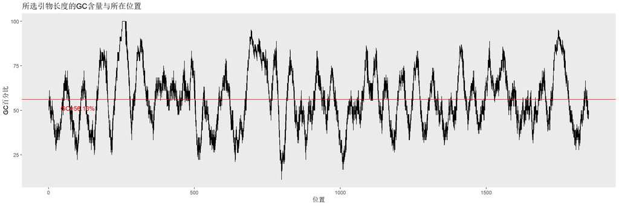

```r
library(ggplot2)

CG_overview <-
  ggplot(data = F_primer_all, aes(x=start, y=GC))+
  geom_line(pch=2) +
  ggtitle("所选引物长度的GC含量与所在位置")+
  labs(x = "位置", y = "GC百分比")+
  geom_hline(aes(yintercept = target_GC), colour = "red") +
  annotate('text', x = 100, y = target_GC-5, label = paste0("GC=",target_GC,"%"), colour = "red") +
  theme(panel.grid = element_blank())

primer_sets_overview <-
  ggplot(data = primer_sets, aes(x=R_start, y =1)) +
  geom_segment(aes(x=0, y=0, xend = target_size, yend = 0))+
  geom_segment(aes(x=target_size-R_start, y = 0.5, xend = target_size-R_end, yend = 0.5),data = primer_sets, color = "red") +
  geom_segment(aes(x=F_start, y = 1, xend = F_end, yend = 1),data = primer_sets, color = "blue")+
  ggtitle("正反向可用引物在靶标上的覆盖")+
  labs(x = "基因位置",y = "")+
  coord_fixed(ratio = 500)+
  theme(axis.ticks = element_blank(),axis.text.y = element_blank())+
  annotate("text",x=0, y = 1, label = "Forward", color = "blue")+
  annotate("text",x=0, y =0.5,label = "Reverse", color = "red")

CG_overview
```

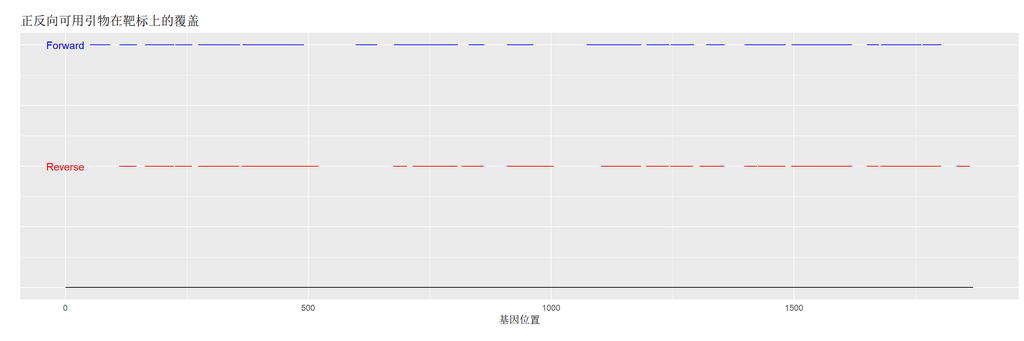

```r
primer_sets_overview
```

## 输出结果到结果目录

```r
outpath <- paste0("../results/", format(start_time,"%y%m%d_%H%M"))

dir.create(outpath)

write.csv(primer_sets,file = paste0(outpath,"/primer_sets.csv"),row.names = F)
```

## 总结

```
## 本次运行耗费时间共44.801
##  设置的引物长度于18与23之间;
##  Tm值于58与63之间;
##  最终的扩增子长度在50到100。
##  共有43025对引物被筛选出来
```